# Population & Sample

Bernard Ade

11-30-2016

Population and sample is at the heart of statistical inference. These two concepts go together like parent and child and without a population there is simply nothing to study. So, Why do we care about population? Because we will like to make **inference** from a study or we will like to draw some conclusion from a subject of interest.

Suppose we are interested in making a conclusion about a particular subject of interest. For instance, what is the average height of males in the United States? This average or mean of US males is known as a **parameter** of the population. This question requires us to gather data on all males in US and calculate the mean. Due to the size and scope of this question, collecting data of every single male in the United States is unreleasitic, so instead we draw a subset of the population and this we call a **sample**. We calculate the average of the random sample, and this we call a **statistic**. Ultimately, the goal is to make inference about the population from a sample.

#### Lets review the terminologies covered so far

- Population is the entire set of the subject we are interested in.
- Sample is a subset of the population.
- Inference is the conclusion that we make from random samples about the population.
- Parameter is some quantity of the population i.e mean, standard deviation.
- Statistic is some quantity of the sample.
- Mean is the average of a set if numbers.
- Standard deviation indicates how spead out the data is from the mean.

Lets use R to put this concept into practice by creating some fake data of a million data points with a mean of 100 and standard deviation of 16. **How close do you think the mean of the sample resembles the mean of the population?**

```r
population = round(rnorm(1000000, mean = 100, sd = 16)) #generate a million data points with a mean of 100
population[1:100] # lets take a peak at the first 100 numbers of our population
```

```
  [1]  76 106  75  81 102  98 114  83  43 103  84 111 117 123 127 117 130 126 106  76 112 103  75 124
 [25]  84  86  88 106 125  99  96  91 105  89 116  88 105  86 116  91 102  89  79  91 114  66  97 110
 [49] 103  73 121  98  84 117  96 109  77 114 100 116 124  97  77  84 122 127 105 102 104  69 129 111
 [73] 114 105 107 103  73  93 110 108 105 103  76  74  98 101  84 109 121  94 124  79 104  96  74  85
 [97] 105 112  95  83
```

##### Lets plot a histogram of our population.

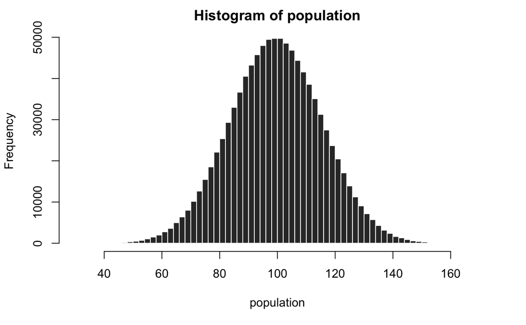

```r
hist(population, col="#333333", border="white", xlim = c(30,170), breaks = 100)
```

##### Now lets take the mean of the population

```r
mean(population)
```

```
[1] 100.0089
```

##### Now lets take 20 random data points from the population and calculate the mean.

```r
sample = sample(population, 20)
mean(sample)
```

```
[1] 103.3
```

##### As you can see above the mean of sample and population are both close to 100. Lets do it a bunch of times. We will write a script that generates a 100 samples of size 20 and calculate the mean of those 100 samples.

```r
sample_means = 0
for(i in 1:100){
  x = sample(population, 20)
  sample_means[i] = mean(x)
}
sample_means
```

```
  [1] 100.70  98.05  99.95  92.35  96.30 100.65  96.70 105.20  97.75  98.65 101.05  99.90  95.25
 [14]  98.00 105.70 100.55 105.00 101.10  99.10  97.90  98.25  97.55  96.75 100.90  95.30  95.55
 [27] 100.60  91.50  99.55 101.70 101.55  96.80  93.25 104.55  97.30 103.50  99.00 104.25  98.95
 [40] 100.75  97.95 101.40  98.50 101.45 106.75 105.55  97.70 100.20 101.70  99.45  99.85 102.40
 [53] 101.10 104.10  97.00 103.35 110.10  98.90 102.50 100.65 102.30 105.30 102.20  96.65 103.75
 [66] 105.10  99.05  98.00  99.85  97.20 100.35 100.65  99.10  96.65 102.10 105.20 105.55  97.05
 [79]  99.40  96.55  97.65 100.20  97.40 101.60 107.85 100.20 100.20  93.30 100.25 100.05  97.15
 [92] 100.35  99.95  98.00 104.15 100.70  98.70  93.90  96.60 101.10
```

##### Above, notice the 100 means for 100 random samples of size 20. Lets plot a histogram of the sample.

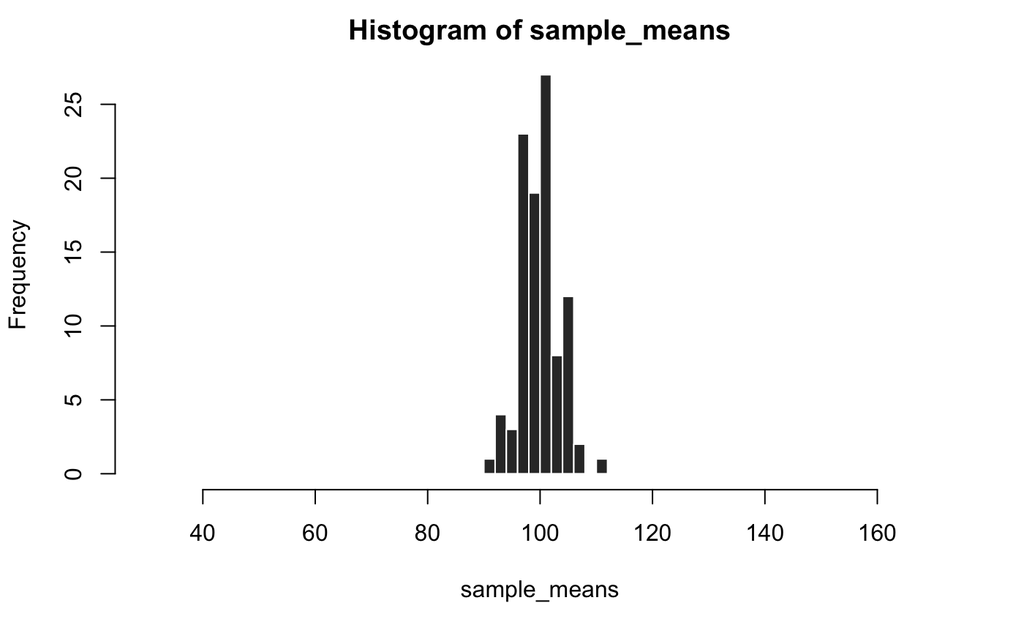

```r
hist(sample_means, col="#333333", border="white", xlim = c(30,170), breaks = 10)
```

As you can see the mean of the population of 1-million data points and the sample of 20 data points are both close to 100. However the standard deviation of the sample has squished in compared to the population. The key here is to understand the intuition behind **estimating a parameter**. Of course, we will have to dive deeper to understand the concept behind randomness. Although in our example the computer randomly selected samples that were well dispersed, accomplishing that randonmness in real life is quite tricky. So we have to employ specific sampling techniques in real life to guarantee randomness, this we call sample bias. Cool that we can simulate these concepts and interactively learn with R.